# Script 3: Practice session 1

# Task 2

Load the data set `Data with which to play.csv` and please plot the following graphs using `ggplot()`:

In the data, Group 1 represents lecturers and Group 2 represents students.

- 1. A bar chart including error bars (95% Cis) of the mean number of friends for students and lecturers. Please also describe the plot: what kind of patterns are you seeing?
- 2. A bar chart including error bars (95% Cis) of the mean alcohol consumption for students and lecturers. Please also describe the plot: what kind of patterns are you seeing?

A few notes:

- Make sure to describe the plots outside of code chunks!
- Remember that you need to compute summary statistics before you can add error bars to a plot.

*Reminder*: This is a code chunk

```r
# code chunk.
```

```r
data <- read_csv("Data with which to play.csv")
data
```

```
## # A tibble: 10 × 7
##    Name     DOB Group Friends Alcohol Income Neurotic
##    <chr>  <dbl> <dbl>   <dbl>   <dbl>  <dbl>    <dbl>
##  1 Leo     1977     1       5      10  20000       10
##  2 Martin  1969     1       2      15  40000       17
##  3 Andy    1973     1       0      20  35000       14
##  4 Paul    1970     1       4       5  22000       13
##  5 Graham  1949     1       1      30  50000       21
##  6 Carina  1983     2      10      25   5000        7
##  7 Karina  1987     2      12      20  10000       13
##  8 Doug    1989     2      15      16   3000        9
##  9 Mark    1973     2      12      17  10000       14
## 10 Mark    1990     2      17      18   5000       13
```

Check data structure

```r
str(data)
```

```
## spc_tbl_ [10 × 7] (S3: spec_tbl_df/tbl_df/tbl/data.frame)
##  $ Name    : chr [1:10] "Leo" "Martin" "Andy" "Paul" ...
##  $ DOB     : num [1:10] 1977 1969 1973 1970 1949 ...
##  $ Group   : num [1:10] 1 1 1 1 1 2 2 2 2 2
##  $ Friends : num [1:10] 5 2 0 4 1 10 12 15 12 17
##  $ Alcohol : num [1:10] 10 15 20 5 30 25 20 16 17 18
##  $ Income  : num [1:10] 20000 40000 35000 22000 50000 5000 10000 3000 10000 5000
##  $ Neurotic: num [1:10] 10 17 14 13 21 7 13 9 14 13
##  - attr(*, "spec")=
##   .. cols(
##   ..   Name = col_character(),
##   ..   DOB = col_double(),
##   ..   Group = col_double(),
##   ..   Friends = col_double(),
##   ..   Alcohol = col_double(),
##   ..   Income = col_double(),
##   ..   Neurotic = col_double()
##   .. )
##  - attr(*, "problems")=<externalptr>
```

We need to make sure that our grouping variable, `Group`, is a factor, otherwise we will get an error later on from `ggplot()`, and since we are here, we could also relabel the factor levels to be more informative

```r
# Transforming the group column from numerical to factor
data$Group <- as.factor(data$Group)

# Re-labeling the factor

data <- data %>%
  mutate(Group = recode_factor(Group,
                               "1" = "Lecturer",
                               "2" = "Student"))

# Check result
data
```

```
## # A tibble: 10 × 7
##    Name     DOB Group    Friends Alcohol Income Neurotic
##    <chr>  <dbl> <fct>      <dbl>   <dbl>  <dbl>    <dbl>
##  1 Leo     1977 Lecturer       5      10  20000       10
##  2 Martin  1969 Lecturer       2      15  40000       17
##  3 Andy    1973 Lecturer       0      20  35000       14
##  4 Paul    1970 Lecturer       4       5  22000       13
##  5 Graham  1949 Lecturer       1      30  50000       21
##  6 Carina  1983 Student       10      25   5000        7
##  7 Karina  1987 Student       12      20  10000       13
##  8 Doug    1989 Student       15      16   3000        9
##  9 Mark    1973 Student       12      17  10000       14
## 10 Mark    1990 Student       17      18   5000       13
```

1. A bar chart including error bars (95% Cis) of the mean number of friends for students and lecturers. Please also describe the plot: what kind of patterns are you seeing?

Since we will be needing error bars, we need to compute summary statistics

```r
data_summary_friends <- summarySE(data, measurevar = "Friends", groupvars = c("Group"))
data_summary_friends
```

```
##      Group N Friends       sd        se       ci
## 1 Lecturer 5     2.4 2.073644 0.9273618 2.574769
## 2  Student 5    13.2 2.774887 1.2409674 3.445478
```

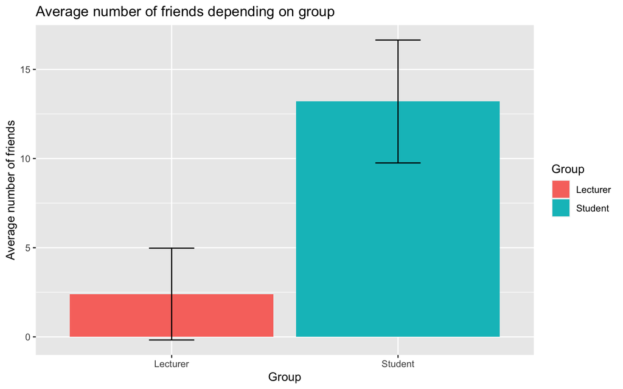

```r
ggplot(data_summary_friends, aes(x=Group, y=Friends, fill = Group)) +
    geom_bar(position=position_dodge(), stat="identity") +
    geom_errorbar(aes(ymin=Friends-ci, ymax=Friends+ci), # Minimum CI threshold = Friends - ci
                                                         # Maximum CI threshold = Friends + ci
                  width=.2,                              # Width of the error bars
                  position=position_dodge(.9))+
  labs(x = "Group", y = "Average number of friends",
       title = "Average number of friends depending on group")
```

What do we learn from this barplot?

Since we will be needing error bars, we need to compute summary statistics

```r
data_summary_alcohol <- summarySE(data, measurevar = "Alcohol", groupvars = c("Group"))
data_summary_alcohol
```

```
##      Group N Alcohol       sd       se        ci
## 1 Lecturer 5    16.0 9.617692 4.301163 11.941942
## 2  Student 5    19.2 3.563706 1.593738  4.424925
```

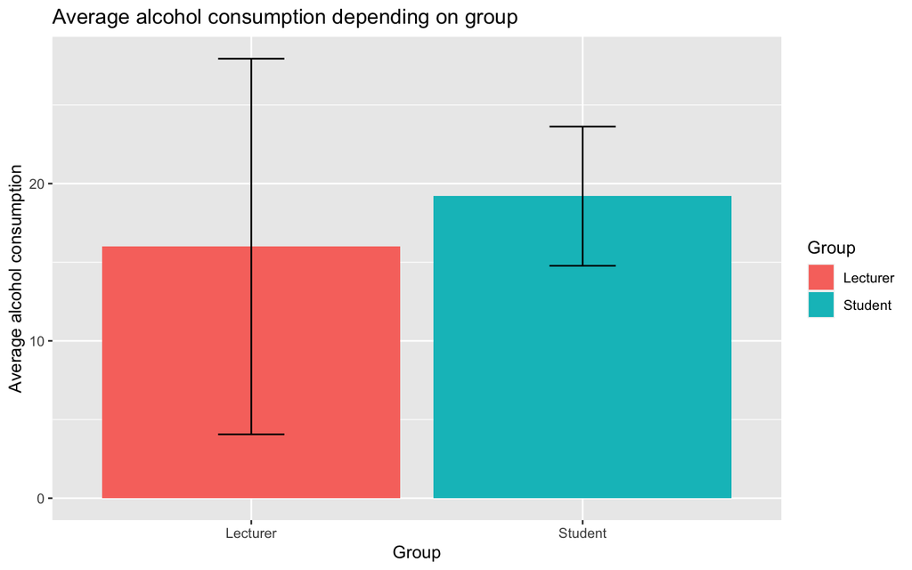

```r
ggplot(data_summary_alcohol, aes(x=Group, y=Alcohol, fill = Group)) +
    geom_bar(position=position_dodge(), stat="identity") +
    geom_errorbar(aes(ymin=Alcohol-ci, ymax=Alcohol+ci), # Minimum CI threshold = Friends - ci
                                                         # Maximum CI threshold = Friends + ci
                  width=.2,                              # Width of the error bars
                  position=position_dodge(.9))+
  labs(x = "Group", y = "Average alcohol consumption",
       title = "Average alcohol consumption depending on group")
```

What do we learn from this barplot?

- On average, students and lecturer display a fairly similar alcohol consumption.
- However, within the lecturer group, the error bars show that there is a very large degree of variation. By contrast, there is not so much variation in the alcohol consumption among students.

# Task 3

Let’s work with the `Data with which to play.csv` a bit more

- 1 Check the structure of the data

```r
str(data)
```

```
## spc_tbl_ [10 × 7] (S3: spec_tbl_df/tbl_df/tbl/data.frame)
##  $ Name    : chr [1:10] "Leo" "Martin" "Andy" "Paul" ...
##  $ DOB     : num [1:10] 1977 1969 1973 1970 1949 ...
##  $ Group   : Factor w/ 2 levels "Lecturer","Student": 1 1 1 1 1 2 2 2 2 2
##  $ Friends : num [1:10] 5 2 0 4 1 10 12 15 12 17
##  $ Alcohol : num [1:10] 10 15 20 5 30 25 20 16 17 18
##  $ Income  : num [1:10] 20000 40000 35000 22000 50000 5000 10000 3000 10000 5000
##  $ Neurotic: num [1:10] 10 17 14 13 21 7 13 9 14 13
##  - attr(*, "spec")=
##   .. cols(
##   ..   Name = col_character(),
##   ..   DOB = col_double(),
##   ..   Group = col_double(),
##   ..   Friends = col_double(),
##   ..   Alcohol = col_double(),
##   ..   Income = col_double(),
##   ..   Neurotic = col_double()
##   .. )
##  - attr(*, "problems")=<externalptr>
```

```r
data
```

```
## # A tibble: 10 × 7
##    Name     DOB Group    Friends Alcohol Income Neurotic
##    <chr>  <dbl> <fct>      <dbl>   <dbl>  <dbl>    <dbl>
##  1 Leo     1977 Lecturer       5      10  20000       10
##  2 Martin  1969 Lecturer       2      15  40000       17
##  3 Andy    1973 Lecturer       0      20  35000       14
##  4 Paul    1970 Lecturer       4       5  22000       13
##  5 Graham  1949 Lecturer       1      30  50000       21
##  6 Carina  1983 Student       10      25   5000        7
##  7 Karina  1987 Student       12      20  10000       13
##  8 Doug    1989 Student       15      16   3000        9
##  9 Mark    1973 Student       12      17  10000       14
## 10 Mark    1990 Student       17      18   5000       13
```

- 1 Build two groups according to age: old and young.

```r
# Filtering
old <-  data %>% # Take the `data` dataset AND
 filter(DOB <= 1970) # filter the dataset such that it includes only the people born before and including 1970

# Take a look at the result
old
```

```
## # A tibble: 3 × 7
##   Name     DOB Group    Friends Alcohol Income Neurotic
##   <chr>  <dbl> <fct>      <dbl>   <dbl>  <dbl>    <dbl>
## 1 Martin  1969 Lecturer       2      15  40000       17
## 2 Paul    1970 Lecturer       4       5  22000       13
## 3 Graham  1949 Lecturer       1      30  50000       21
```

```r
young <- data %>%
  filter(DOB > 1970)

young
```

```
## # A tibble: 7 × 7
##   Name     DOB Group    Friends Alcohol Income Neurotic
##   <chr>  <dbl> <fct>      <dbl>   <dbl>  <dbl>    <dbl>
## 1 Leo     1977 Lecturer       5      10  20000       10
## 2 Andy    1973 Lecturer       0      20  35000       14
## 3 Carina  1983 Student       10      25   5000        7
## 4 Karina  1987 Student       12      20  10000       13
## 5 Doug    1989 Student       15      16   3000        9
## 6 Mark    1973 Student       12      17  10000       14
## 7 Mark    1990 Student       17      18   5000       13
```

- 2 Compute the average alcohol intake for each group and compare the values.

```r
mean_alc_old <- mean(old$Alcohol)
```

```r
mean_alc_young <- mean(young$Alcohol)
```

```r
mean_alc_old > mean_alc_young # F
```

```
## [1] FALSE
```

```r
mean_alc_old == mean_alc_young # F
```

```
## [1] FALSE
```

```r
mean_alc_old >= mean_alc_young # F
```

```
## [1] FALSE
```

```r
mean_alc_old <= mean_alc_young # T
```

```
## [1] TRUE
```

```r
mean_alc_old < mean_alc_young #T
```

```
## [1] TRUE
```

- 3 Summarize the data! Use the function that allows you to summarize the neuroticism scores. Note that when summarizing the data, the grouping variable should be `Group`.

*Hint*: You have encountered this function before when you needed to compute summary statistics such as the standard deviation, standard error, mean and confidence intervals to add error bars to a plot.

```r
summary_neurotic <- summarySE(data, measurevar = "Neurotic", groupvars = "Group")
summary_neurotic
```

```
##      Group N Neurotic      sd       se       ci
## 1 Lecturer 5     15.0 4.18330 1.870829 5.194253
## 2  Student 5     11.2 3.03315 1.356466 3.766153
```

# Task 4

**Plotting within-participants vs. between-participants data**

We will be working with the same data, just entered differently. The data comes from an eye-tracking study with a 1-factor, 2-levels design (factor: parallelism, levels: parallel vs. non-parallel). Originally, these were data from a repeated-measured (within-subjects) design.

- In the file *reading_indep.sav*, the data were entered as if originating from a between-subject design.
- In the file *reading.sav*, the data were entered as if originating from a within-subject design.

**Loading in the data**

```r
reading_within <- read_sav("reading.sav")
reading_between <- read_sav("reading_indep.sav")
```

Let’s plot the average reading times as a function of condition for each of the two files.

**Plotting the between-subjects data**

Check the structure of the between-subjects data. For each level of the parallelism factor 1 and 2, there is one corresponding reading time value. However, notice that the paralellism factor is coded with 1 and 2.

```r
reading_between
```

```
## # A tibble: 32 × 3
##     subj parallelism reading_times
##    <dbl> <dbl+lbl>           <dbl>
##  1     1 2 [nonpara]         1248
##  2     2 2 [nonpara]         1044
##  3     3 2 [nonpara]         1102
##  4     4 2 [nonpara]          877
##  5     5 2 [nonpara]         1346.
##  6     6 2 [nonpara]         1196
##  7     7 2 [nonpara]         1290.
##  8     8 2 [nonpara]          734
##  9     9 2 [nonpara]         1024.
## 10    10 2 [nonpara]          909
## # … with 22 more rows
```

In order to plot the data, we need out categorical variable to be coded as a factor. Let’s check if that’s the case

```r
typeof(reading_between$parallelism) # double
```

```
## [1] "double"
```

Since `parallelism` is currently a numerical variable (double), we need to convert it to a factor.

```r
reading_between$parallelism <- as.factor(reading_between$parallelism)
str(reading_between) # the parallelism is now coded as a factor
```

```
## tibble [32 × 3] (S3: tbl_df/tbl/data.frame)
##  $ subj         : num [1:32] 1 2 3 4 5 6 7 8 9 10 ...
##   ..- attr(*, "format.spss")= chr "F2.0"
##  $ parallelism  : Factor w/ 2 levels "1","2": 2 2 2 2 2 2 2 2 2 2 ...
##  $ reading_times: num [1:32] 1248 1044 1102 877 1346 ...
##   ..- attr(*, "format.spss")= chr "F16.2"
##   ..- attr(*, "display_width")= int 16
```

Remember that in order to create a barplot with error bars, you need to compute some summary statistics. Please compute summary statistics for the `reading_between` data. Think about the function that you need to use.

Hint: It is the same function that we have been using to create summary statistics before adding error bars to a plot.

```r
reading_between_summary <- summarySE(reading_between,  measurevar = "reading_times", groupvars = "parallelism")

# Check the result
reading_between_summary
```

```
##   parallelism  N reading_times       sd        se       ci
## 1           1 16      1045.844 356.8580  89.21451 190.1562
## 2           2 16      1228.751 408.5155 102.12888 217.6826
```

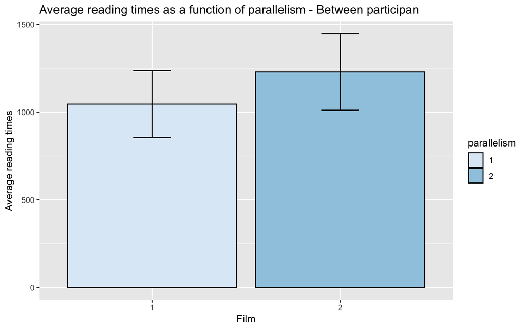

```r
ggplot(data = reading_between_summary, aes(x = parallelism, y = reading_times, fill = parallelism))+
  geom_bar(position = "dodge",
           stat = "summary",
           fun = "mean",
           color="black")+
   geom_errorbar(aes(ymin=reading_times-ci, ymax=reading_times+ci), # Minimum CI threshold = mean - ci (from reading_within_summary)
                                                         # Maximum CI threshold = mean + ci (from reading_within_summary)
                  width=.2,                              # Width of the error bars
                  position=position_dodge(.9))+
  labs(x = "Film", y = "Average reading times", fill = "parallelism",
       title = "Average reading times as a function of parallelism - Between participan")+
  scale_fill_brewer(palette = "Blues")
```

**Plotting the within-subjects data**

To plot the within-subjects data, we first need to bring the data in the tall format, where each factor level is assigned a value. Otherwise, the `ggplot()` function cannot work with the data.

```r
reading_within_tall <- reading_within %>%
   pivot_longer(cols = 2:3, names_to = "parallelism", values_to = "reading_times", values_drop_na = TRUE)

# Check the result
reading_within_tall
```

```
## # A tibble: 32 × 3
##     subj parallelism reading_times
##    <dbl> <chr>               <dbl>
##  1     1 pa_und              1123.
##  2     1 np_und              1248
##  3     2 pa_und               738.
##  4     2 np_und              1044
##  5     3 pa_und              1010.
##  6     3 np_und              1102
##  7     4 pa_und              1064.
##  8     4 np_und               877
##  9     5 pa_und               786.
## 10     5 np_und              1346.
## # … with 22 more rows
```

```r
# Make sure that parallelism is a factor
reading_within_tall$parallelism <- as.factor(reading_within_tall$parallelism)

# Make sure that the subject column is a factor
reading_within_tall$subj <- as.factor(reading_within_tall$subj)
```

To add the error bars we also need to compute summary statistics

```r
# Compute a summary statistics to add 95% CI error bars
reading_within_summary <-summarySE(reading_within_tall, measurevar = "reading_times", groupvars = "parallelism")

# Check the result
reading_within_summary
```

```
##   parallelism  N reading_times       sd        se       ci
## 1      np_und 16      1228.751 408.5155 102.12888 217.6826
## 2      pa_und 16      1045.844 356.8580  89.21451 190.1562
```

You’ve seen these values before, right? That is because the data as it is now, is the same as for the between-participants data. We need to find a way to remove some of the variability among participants, since this data comes from a repeated-measures design. Luckily, there’s a quick and easy way to do this. All you need to do is use the `summarySEwithin()` function. It summarizes data, handling within-subjects variables by removing inter-subject variability.

```r
# Compute an summary statistics adjusted to within-participants design
reading_within_summary_adjusted <-summarySEwithin(reading_within_tall, measurevar = "reading_times", withinvars = "parallelism", idvar = "subj")

# Check the result
reading_within_summary_adjusted
```

```
##   parallelism  N reading_times       sd       se       ci
## 1      np_und 16      1228.751 236.6294 59.15735 126.0909
## 2      pa_und 16      1045.844 236.6294 59.15735 126.0909
```

Notice the differences in the `sd`, `se`, `ci` columns.

**Plotting the average reading times as a function of parallelism for the within-participants data**

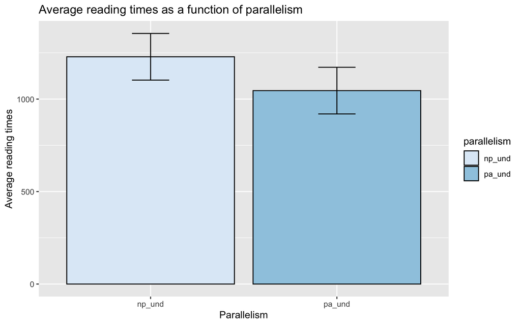

```r
ggplot(data = reading_within_summary_adjusted, aes(x = parallelism, y = reading_times, fill = parallelism))+
  geom_bar(position = "dodge",
           stat = "summary",
           fun = "mean",
           color="black")+
   geom_errorbar(aes(ymin=reading_times-ci, ymax=reading_times+ci), # Minimum CI threshold = mean - ci (from reading_within_summary)
                                                         # Maximum CI threshold = mean + ci (from reading_within_summary)
                  width=.2,                              # Width of the error bars
                  position=position_dodge(.9))+
  labs(x = "Parallelism", y = "Average reading times", fill = "parallelism",
       title = "Average reading times as a function of parallelism")+
  scale_fill_brewer(palette = "Blues")
```

Keep the steps of this task in mind for Task 5.

# Task 5:

**The following task is taken over from this week’s SPSS handout:**

The data set for task 4 comes from an eye-tracking reading study in which we manipulated 2 factors within participants. A first factor was ‘parallelism’, that is whether two clauses had parallel or non-parallel word order (both clauses have object-subject word order; one clause has subject-object word order while the other clause has object-subject word order). A second factor was conjunction (whether the conjunction that linked the 2 clauses was ‘und’ or ‘während’) . • You can find the data in the file data QuestionSet1.sav • In the file ‘np’ in the variable names refers to ‘non-parallel word order’ and ‘pa’ refers to parallel word order. The variable names identify the four conditions.

• Expectations: It’s been shown that reading times during the second clause of coordinate structures are faster when the structure of the first and second clause are similar relative to when they differ. This has been dubbed ‘parallelism facilitation’. If this finding replicates, we should see that clauses with parallel word order should be read faster than clauses with nonparallel word order. It’s also interesting to ask whether it’s purely repetition of structure that procures faster reading times, or whether the conjunction plays a role. ‘And’ expresses that two things are similar and might thus heighten effects of parallelism (coordination of ‘like’ structures). ‘Während’ by contrast, can be used with a temporal but also with contrastive meaning and if the conjunction plays a role in parallelism facilitation, a conjunction that is not expressing similarity of things may rather reduce parallelism facilitation.

- 1: Load the *QuestionSet1.csv* data. Use the read_csv() function. Type ?read_csv() to see how to supply arguments to the function.

```r
question_dat <- read_csv(file = "QuestionSet1.csv")
```

- 2: Please produce a bar graph that illustrates the interaction effect of parallelism and conjunction - this means that both parallelism and conjunction should appear in your barplot. The graph should plot the 4 conditions and also plot the error bars (95 % confidence intervals).

Hint: If you feel stuck go back to the week 1 script to remember how to build a barplot. Consider all preparation steps we followed in the previous task.

```r
# Since this is a within-subjects dataset we will summarizare our data using the function summarySEwithin()

summary_question_dat <- summarySEwithin(question_dat, measurevar = "reading_times",withinvars = "condition")
summary_question_dat
```

```
##    condition  N reading_times       sd        se       ci
## 1     np_und 32     1104.4318 568.1515 100.43594 204.8405
## 2 np_während 32     1039.8862 468.9857  82.90574 169.0874
## 3     pa_und 32      933.5329 460.7695  81.45330 166.1251
## 4 pa_während 32     1025.1387 422.8686  74.75331 152.4604
```

Drawing the plot

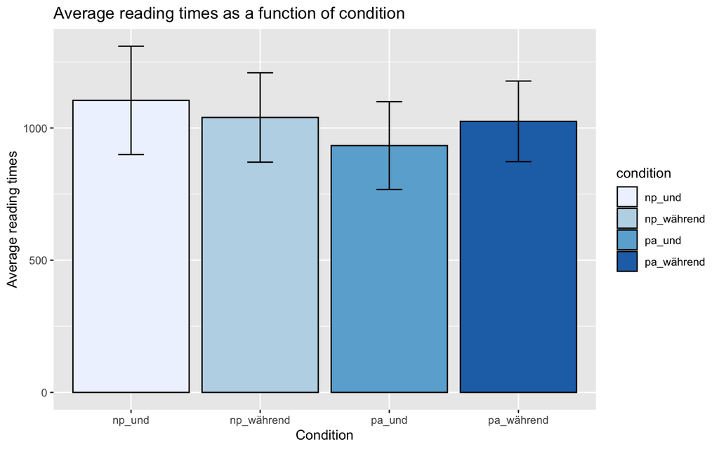

```r
ggplot(data = summary_question_dat, aes(x = condition, y = reading_times, fill = condition))+
  geom_bar(position = "dodge",
           stat = "summary",
           fun = "mean",
           color="black")+
   geom_errorbar(aes(ymin=reading_times-ci, ymax=reading_times+ci), # Minimum CI threshold = mean - ci (from reading_within_summary)
                                                         # Maximum CI threshold = mean + ci (from reading_within_summary)
                  width=.2,                              # Width of the error bars
                  position=position_dodge(.9))+
  labs(x = "Condition", y = "Average reading times", fill = "condition",
       title = "Average reading times as a function of condition")+
  scale_fill_brewer(palette = "Blues")
```

- 3: Describe briefly how you computed adjusted summary statistics for the present data. Which function did you use and why?

The adjusted summary statistics were computed using the function `summarySEwithin()`

# End of script:

Please make sure to hand in the script before the set deadline. Please only submit scripts that can run and can be knitted without any errors.